# R Notebook

# Setting up the environment for analysis

# scraping with API

We will be working with crime data in 2016

|  | ID | Case.Number | Date | Block | IUCR | Primary.Type | Description | Location.Description | Arrest | Domestic | Beat | District | Ward | Community.Area | FBI.Code | X.Coordinate | Y.Coordinate | Year | Updated.On | Latitude | Longitude | Location |
| --- | --- | --- | --- | --- | --- | --- | --- | --- | --- | --- | --- | --- | --- | --- | --- | --- | --- | --- | --- | --- | --- | --- |
| 1 | 10372201 | HZ108010 |  | 071XX N MANKATO AVE | 2820 | OTHER OFFENSE | TELEPHONE THREAT | RESIDENCE | true | false | 1621 | 16 | 41 | 12 | 26 | 1135130 | 1947162 | 2016 |  | 42.01120 | -87.77815 | (42.011203975, -87.77814883) |
| 2 | 10375758 | HZ111926 |  | 076XX N SHERIDAN RD | 0820 | THEFT | $500 AND UNDER | SIDEWALK | true | false | 2422 | 24 | 49 | 1 | 06 | 1165527 | 1950516 | 2016 |  | 42.01981 | -87.66621 | (42.019811963, -87.666209262) |
| 3 | 10376371 | HZ112605 |  | 004XX E 48TH ST | 0910 | MOTOR VEHICLE THEFT | AUTOMOBILE | STREET | true | false | 223 | 2 | 3 | 38 | 07 | 1180055 | 1873293 | 2016 |  | 41.80759 | -87.61513 | (41.807586328, -87.615127788) |
| 4 | 10378473 | HZ114778 |  | 023XX W TOUHY AVE | 0486 | BATTERY | DOMESTIC BATTERY SIMPLE | APARTMENT | true | false | 2411 | 24 | 49 | 2 | 08B | 1159245 | 1947721 | 2016 |  | 42.01227 | -87.68940 | (42.012274439, -87.689403816) |
| 5 | 10380488 | HZ116467 |  | 091XX S PAXTON AVE | 4387 | OTHER OFFENSE | VIOLATE ORDER OF PROTECTION | RESIDENCE | true | true | 413 | 4 | 7 | 48 | 26 | 1192434 | 1844707 | 2016 |  | 41.72885 | -87.57066 | (41.728851343, -87.570655525) |
| 6 | 10380619 | HZ116583 |  | 091XX S PAXTON AVE | 4387 | OTHER OFFENSE | VIOLATE ORDER OF PROTECTION | RESIDENCE | true | true | 413 | 4 | 7 | 48 | 26 | 1192434 | 1844707 | 2016 |  | 41.72885 | -87.57066 | (41.728851343, -87.570655525) |

The data clearly shows how there are lots of missing data. In particular, the `Date` column is done practially useless. This is perfectly fine, because the objective of this project is to create point graphs and choropleth graphs, which do not have inherent date specifications.

```r
dim(crime.data)
```

```
[1] 268756     22
```

```r
dim(narc.data)
```

```
[1] 952  22
```

Now the data is in a much more reasonable size. 952 rows! But we definitely do not need all the columns

```r
names(narc.data)
```

[output not shown]

For our analysis, we only really need the `Community.Area`, `Latitute`, and `Longitude`.

|  | comm | lat | long |
| --- | --- | --- | --- |
| 1 | 25 | 41.88019 | -87.76853 |
| 2 | 8 | 41.90313 | -87.63218 |
| 3 | 29 | 41.86631 | -87.71376 |
| 4 | 26 | 41.88075 | -87.72398 |
| 5 | 23 | 41.89807 | -87.71640 |
| 6 | 23 | 41.89905 | -87.72291 |

# Creating a point layer

```r
dim(narc.coord)
```

```
[1] 951   3
```

There is one data point without coordinates

Within the `sf` package, there is the `st_as_sf` function that converts coordinates to spatial objects. So, this is the command that we will be using:

```r
class(narc.points)
```

```
[1] "sf"         "data.frame"
```

Now that we are certain that this is in the correct format, we will plot the points

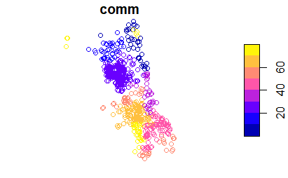

## Community Area boundary file

`sf` can read a geojson formatted file directly from the web, and we will exploit that functionality. So we will call this information directly from the Chicago Data Portal.

```r
chicago.comm <- read_sf(comm.file)
chicago.comm <- read_sf(comm.file)
class(chicago.comm)
```

```
[1] "sf"         "tbl_df"     "tbl"        "data.frame"
```

```r
st_crs(chicago.comm)
```

```
Coordinate Reference System:
  EPSG: 4326
  proj4string: "+proj=longlat +datum=WGS84 +no_defs"
```

```r
head(chicago.comm)
```

```
Simple feature collection with 6 features and 9 fields
geometry type:  MULTIPOLYGON
dimension:      XY
bbox:           xmin: -87.7069 ymin: 41.79448 xmax: -87.58001 ymax: 41.99076
epsg (SRID):    4326
proj4string:    +proj=longlat +datum=WGS84 +no_defs
```

| community | area | shape_area | perimeter | area_num_1 | area_numbe | comarea_id | comarea | shape_len | geometry |
| --- | --- | --- | --- | --- | --- | --- | --- | --- | --- |
| DOUGLAS | 0 | 46004621.1581 | 0 | 35 | 35 | 0 | 0 | 31027.0545098 |  |
| OAKLAND | 0 | 16913961.0408 | 0 | 36 | 36 | 0 | 0 | 19565.5061533 |  |
| FULLER PARK | 0 | 19916704.8692 | 0 | 37 | 37 | 0 | 0 | 25339.0897503 |  |
| GRAND BOULEVARD | 0 | 48492503.1554 | 0 | 38 | 38 | 0 | 0 | 28196.8371573 |  |
| KENWOOD | 0 | 29071741.9283 | 0 | 39 | 39 | 0 | 0 | 23325.1679062 |  |
| LINCOLN SQUARE | 0 | 71352328.2399 | 0 | 4 | 4 | 0 | 0 | 36624.6030848 |  |

Before moving on to the spatial join operation, we will convert both the community area boundaries and the narcotics points to the same projection, using the `st_transform` command. We assign the UTM (Universal Tranverse Mercator) zone 16N, which the the proper one for Chicago, with an EPSG code of 32616. After the projection transformation, we check the result using `st_crs`.

```r
chicago.comm <- st_transform(chicago.comm,32616)
st_crs(chicago.comm)
```

```
Coordinate Reference System:
  EPSG: 32616
  proj4string: "+proj=utm +zone=16 +datum=WGS84 +units=m +no_defs"
```

```r
narc.points <- st_transform(narc.points,32616)
st_crs(narc.points)
```

```
Coordinate Reference System:
  EPSG: 32616
  proj4string: "+proj=utm +zone=16 +datum=WGS84 +units=m +no_defs"
```

# Spatial Join

```r
comm.pts <- st_join(narc.points, chicago.comm["area_num_1"])
head(comm.pts)
```

```
Simple feature collection with 6 features and 2 fields
geometry type:  POINT
dimension:      XY
bbox:           xmin: 436232.5 ymin: 4635179 xmax: 447564.7 ymax: 4639214
epsg (SRID):    32616
proj4string:    +proj=utm +zone=16 +datum=WGS84 +units=m +no_defs
  comm area_num_1                 geometry
1   25         25 POINT (436232.5 4636759)
2    8          8 POINT (447564.7 4639214)
3   29         29 POINT (440763.9 4635179)
4   26         26 POINT (439929.6 4636789)
5   23         23 POINT (440574.7 4638708)
6   23         23 POINT (440035.9 4638821)
```

```r
is.numeric(comm.pts$area_num_1)
```

```
[1] TRUE
```

```r
comm.pts$area_num_1 <- as.integer(comm.pts$area_num_1)
is.integer(comm.pts$area_num_1)
```

```
[1] TRUE
```

```r
chicago.comm$area_num_1 <- as.integer(chicago.comm$area_num_1)
```

# Counts by community area

```r
st_geometry(comm.pts) <- NULL
class(comm.pts)
```

```
[1] "data.frame"
```

```r
narc.cnts <- comm.pts %>% count(area_num_1)
narc.cnts <- narc.cnts %>% rename(comm = area_num_1, AGG.COUNT = n)
head(narc.cnts)
```

| comm | AGG.COUNT |
| --- | --- |
| 1 | 5 |
| 2 | 6 |
| 3 | 9 |
| 4 | 4 |
| 5 | 2 |
| 6 | 3 |

# Mapping the Narcotics counts

```r
chicago.comm <- left_join(chicago.comm,narc.cnts, by = c("area_num_1" = "comm"))
head(chicago.comm)
```

```
Simple feature collection with 6 features and 10 fields
geometry type:  MULTIPOLYGON
dimension:      XY
bbox:           xmin: 441440.4 ymin: 4627153 xmax: 451817.1 ymax: 4648971
epsg (SRID):    32616
proj4string:    +proj=utm +zone=16 +datum=WGS84 +units=m +no_defs
```

| community | area | shape_area | perimeter | area_num_1 | area_numbe | comarea_id | comarea | shape_len | AGG.COUNT | geometry |
| --- | --- | --- | --- | --- | --- | --- | --- | --- | --- | --- |
| DOUGLAS | 0 | 46004621.1581 | 0 | 35 | 35 | 0 | 0 | 31027.0545098 | 7 |  |
| OAKLAND | 0 | 16913961.0408 | 0 | 36 | 36 | 0 | 0 | 19565.5061533 | NA |  |
| FULLER PARK | 0 | 19916704.8692 | 0 | 37 | 37 | 0 | 0 | 25339.0897503 | 1 |  |
| GRAND BOULEVARD | 0 | 48492503.1554 | 0 | 38 | 38 | 0 | 0 | 28196.8371573 | 4 |  |
| KENWOOD | 0 | 29071741.9283 | 0 | 39 | 39 | 0 | 0 | 23325.1679062 | 4 |  |
| LINCOLN SQUARE | 0 | 71352328.2399 | 0 | 4 | 4 | 0 | 0 | 36624.6030848 | 4 |  |

# Basic choropleth map

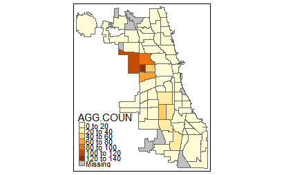

```r
tm_shape(chicago.comm) +
  tm_polygons("AGG.COUNT")
```

# ——————————————————————–

# Extracting a pdf file

We will use the `pdftools` package to turn the contents of a pdf file into a list of long character strings.

```r
pop.dat[1]
```

```
[1] "                                                                            Population and Poverty Data by Chicago Community Area, updated December 2016\r\n                                                                                                                                           …
```

We realize that this extracts each page as a single entry.

```r
length(pop.dat)
```

[output not shown]

We will extract the population information from this unknown data type of strings. This information will be initialized in `nnlist`. We will store each line into this list, by parsing it with the new line character `/n`.

```r
ppage[[1]]
```

```
 [1] "                                                                            Population and Poverty Data by Chicago Community Area, updated December 2016\r"
 [2] "                                                                                                                                                                                                                         Percent of Children\r"
 [3] "                                                                                                                                                                                                                       Below 185% of Poverty\r"
 [4] "                                                                                                                                                                      Percent of Children with Percent of Children in Level (Income Eligible for\r"
 [5] "                                                            Population                                           Race/Ethnicity of Total Population                   All Parents in Labor Force     Poverty           Child Care Assistance)\r"
 [6] "                                                                                                                                                       Percent Non‐\r"
 [7] "                        Community\r"
 [8] "                                                                                                                              Percent                    Hispanic\r"
 [9] "                                                                                      Families                 Percent Non‐    Non‐     Percent Non‐     Other or\r"
[10] "                                      Total       Age       Age             Age     with a child   Percent       Hispanic     Hispanic    Hispanic       Multiple      Children     Children     Children  Children      Children     Children\r"
[11] "     Community          Number      Population    0‐2       3‐4    Age 5    6‐12    under age 6    Hispanic        Black       White       Asian          Races          0‐5          6‐17         0‐5       6‐11          0‐5          6‐11\r"
[12] "Rogers Park                 1           54,402      2,131    1,196    809     3,577       2,875          24%            24%        42%            6%             3%          58%           66%         26%       33%           45%          72%\r"
[13] "West Ridge                  2           72,211      3,547    1,987    993     7,113       4,072          18%            11%        44%           23%             4%          54%           67%         30%       38%           52%          59%\r"
[14] "Uptown                      3           55,137      1,459      857    279     2,244       1,860          12%            21%        55%            9%             4%          71%           68%         23%       33%           37%          63%\r"
[15] "Lincoln Square              4           40,761      1,939      955    300     2,199       2,243          18%             3%        65%           11%             3%          60%           65%         12%       17%           24%          29%\r"
```

[output cut: 39 more lines]

The first eleven lines are useless for our purpose. So, we will eliminate them

```r
nni
```

```
 [1] "Rogers Park                 1           54,402      2,131    1,196    809     3,577       2,875          24%            24%        42%            6%             3%          58%           66%         26%       33%           45%          72%\r"
 [2] "West Ridge                  2           72,211      3,547    1,987    993     7,113       4,072          18%            11%        44%           23%             4%          54%           67%         30%       38%           52%          59%\r"
 [3] "Uptown                      3           55,137      1,459      857    279     2,244       1,860          12%            21%        55%            9%             4%          71%           68%         23%       33%           37%          63%\r"
 [4] "Lincoln Square              4           40,761      1,939      955    300     2,199       2,243          18%             3%        65%           11%             3%          60%           65%         12%       17%           24%          29%\r"
 [5] "North Center                5           34,623      1,934    1,042    456     2,613       2,317          14%             2%        76%            4%             3%          71%           78%          3%        4%            6%          12%\r"
 [6] "Lake View                   6           98,212      3,770    1,427    865     3,271       4,131           7%             3%        80%            7%             3%          75%           69%          5%        7%            9%          13%\r"
 [7] "Lincoln Park                7           66,959      2,335    1,438    487     3,423       2,775           7%             5%        80%            6%             3%          68%           54%          6%        6%            7%          10%\r"
 [8] "Near North Side             8           89,465      2,343      927    312     2,516       2,529           5%             9%        72%           11%             3%          63%           64%         16%       36%           20%          41%\r"
 [9] "Edison Park                 9           11,356        260      293     40     1,130          411          9%             1%        87%            1%             1%          63%           70%          0%        0%            4%           4%\r"
[10] "Norwood Park               10           36,083      1,249    1,033    432     2,882       1,772          12%             1%         81%           4%             2%          75%           82%          5%        6%           12%          13%\r"
[11] "Jefferson Park             11           27,264      1,004      935    198     1,938       1,417          23%             1%        65%            9%             2%          62%           75%         14%       10%           26%          30%\r"
[12] "Forest Glen                12           18,437        562      661    212     2,120          936         12%             1%        72%           13%             2%          78%           76%          3%        3%            9%           8%\r"
[13] "North Park                 13           18,442        644      591    255     1,379          947         20%             3%        51%           25%             2%          61%           74%         34%        8%           51%          39%\r"
[14] "Albany Park                14           52,079      2,134    1,643    645     4,428       2,884          48%             4%         29%          16%             2%          61%           74%         26%       34%           49%          60%\r"
[15] "Portage Park               15           64,846      2,415    1,421    968     5,210       3,335          42%             1%         50%           4%             2%          68%           69%         16%       22%           38%          43%\r"
```

[output cut: 28 more lines]

Now we append this with the information on the next page:

```r
nnu <- unlist(nni)
nnlist <- c(nnlist,nnu)
nnlist <- ""
for (i in 1:2) {
  ppage <- strsplit(pop.dat[[i]],split="\n")
  nni <- ppage[[1]]
  nni <- nni[-(1:11)]
  nnu <- unlist(nni)
  nnlist <- c(nnlist,nnu)
}
# we extract the first and last elements, as they are not meaningful to our analysis
nnlist <- nnlist[2:(length(nnlist)-2)]
nnlist <- nnlist[-43]
```